# Project: Identify Customer Segments

In this project, you will apply unsupervised learning techniques to identify segments of the population that form the core customer base for a mail-order sales company in Germany. These segments can then be used to direct marketing campaigns towards audiences that will have the highest expected rate of returns. The data that you will use has been provided by our partners at Bertelsmann Arvato Analytics, and represents a real-life data science task.

This notebook will help you complete this task by providing a framework within which you will perform your analysis steps. In each step of the project, you will see some text describing the subtask that you will perform, followed by one or more code cells for you to complete your work. **Feel free to add additional code and markdown cells as you go along so that you can explore everything in precise chunks.** The code cells provided in the base template will outline only the major tasks, and will usually not be enough to cover all of the minor tasks that comprise it.

It should be noted that while there will be precise guidelines on how you should handle certain tasks in the project, there will also be places where an exact specification is not provided. **There will be times in the project where you will need to make and justify your own decisions on how to treat the data.** These are places where there may not be only one way to handle the data. In real-life tasks, there may be many valid ways to approach an analysis task. One of the most important things you can do is clearly document your approach so that other scientists can understand the decisions you've made.

At the end of most sections, there will be a Markdown cell labeled **Discussion**. In these cells, you will report your findings for the completed section, as well as document the decisions that you made in your approach to each subtask. **Your project will be evaluated not just on the code used to complete the tasks outlined, but also your communication about your observations and conclusions at each stage.**

```python
# import libraries here; add more as necessary
import numpy as np
import pandas as pd
import matplotlib.pyplot as plt
import seaborn as sns

from sklearn.preprocessing import Imputer, StandardScaler
from sklearn.decomposition import PCA
from sklearn.cluster import KMeans

# magic word for producing visualizations in notebook
%matplotlib inline
```

### Step 0: Load the Data

Each row of the demographics files represents a single person, but also includes information outside of individuals, including information about their household, building, and neighborhood. You will use this information to cluster the general population into groups with similar demographic properties. Then, you will see how the people in the customers dataset fit into those created clusters. The hope here is that certain clusters are over-represented in the customers data, as compared to the general population; those over-represented clusters will be assumed to be part of the core userbase. This information can then be used for further applications, such as targeting for a marketing campaign.

To start off with, load in the demographics data for the general population into a pandas DataFrame, and do the same for the feature attributes summary. Note for all of the `.csv` data files in this project: they're semicolon (`;`) delimited, so you'll need an additional argument in your [`read_csv()`](https://pandas.pydata.org/pandas-docs/stable/generated/pandas.read_csv.html) call to read in the data properly. Also, considering the size of the main dataset, it may take some time for it to load completely.

Once the dataset is loaded, it's recommended that you take a little bit of time just browsing the general structure of the dataset and feature summary file. You'll be getting deep into the innards of the cleaning in the first major step of the project, so gaining some general familiarity can help you get your bearings.

```python
# Load in the general demographics data.
azdias = pd.read_csv('Udacity_AZDIAS_Subset.csv',sep=';')

# Load in the feature summary file.
feat_info = pd.read_csv('AZDIAS_Feature_Summary.csv',sep=';')
```

```python
# Check the structure of the data after it's loaded (e.g. print the number of
# rows and columns, print the first few rows).
azdias.head()
```

|  | AGER_TYP | ALTERSKATEGORIE_GROB | ANREDE_KZ | CJT_GESAMTTYP | FINANZ_MINIMALIST | FINANZ_SPARER | FINANZ_VORSORGER | FINANZ_ANLEGER | FINANZ_UNAUFFAELLIGER | FINANZ_HAUSBAUER | ... | PLZ8_ANTG1 | PLZ8_ANTG2 | PLZ8_ANTG3 | PLZ8_ANTG4 | PLZ8_BAUMAX | PLZ8_HHZ | PLZ8_GBZ | ARBEIT | ORTSGR_KLS9 | RELAT_AB |
| --- | --- | --- | --- | --- | --- | --- | --- | --- | --- | --- | --- | --- | --- | --- | --- | --- | --- | --- | --- | --- | --- |
| 0 | -1 | 2 | 1 | 2.0 | 3 | 4 | 3 | 5 | 5 | 3 | ... | NaN | NaN | NaN | NaN | NaN | NaN | NaN | NaN | NaN | NaN |
| 1 | -1 | 1 | 2 | 5.0 | 1 | 5 | 2 | 5 | 4 | 5 | ... | 2.0 | 3.0 | 2.0 | 1.0 | 1.0 | 5.0 | 4.0 | 3.0 | 5.0 | 4.0 |
| 2 | -1 | 3 | 2 | 3.0 | 1 | 4 | 1 | 2 | 3 | 5 | ... | 3.0 | 3.0 | 1.0 | 0.0 | 1.0 | 4.0 | 4.0 | 3.0 | 5.0 | 2.0 |
| 3 | 2 | 4 | 2 | 2.0 | 4 | 2 | 5 | 2 | 1 | 2 | ... | 2.0 | 2.0 | 2.0 | 0.0 | 1.0 | 3.0 | 4.0 | 2.0 | 3.0 | 3.0 |
| 4 | -1 | 3 | 1 | 5.0 | 4 | 3 | 4 | 1 | 3 | 2 | ... | 2.0 | 4.0 | 2.0 | 1.0 | 2.0 | 3.0 | 3.0 | 4.0 | 6.0 | 5.0 |

5 rows × 85 columns

```python
azdias.sample(10)
```

|  | AGER_TYP | ALTERSKATEGORIE_GROB | ANREDE_KZ | CJT_GESAMTTYP | FINANZ_MINIMALIST | FINANZ_SPARER | FINANZ_VORSORGER | FINANZ_ANLEGER | FINANZ_UNAUFFAELLIGER | FINANZ_HAUSBAUER | ... | PLZ8_ANTG1 | PLZ8_ANTG2 | PLZ8_ANTG3 | PLZ8_ANTG4 | PLZ8_BAUMAX | PLZ8_HHZ | PLZ8_GBZ | ARBEIT | ORTSGR_KLS9 | RELAT_AB |
| --- | --- | --- | --- | --- | --- | --- | --- | --- | --- | --- | --- | --- | --- | --- | --- | --- | --- | --- | --- | --- | --- |
| 550690 | -1 | 2 | 1 | 3.0 | 2 | 5 | 1 | 4 | 5 | 3 | ... | 2.0 | 4.0 | 3.0 | 1.0 | 3.0 | 4.0 | 3.0 | 4.0 | 7.0 | 3.0 |
| 805182 | -1 | 1 | 1 | 4.0 | 3 | 4 | 3 | 5 | 5 | 3 | ... | NaN | NaN | NaN | NaN | NaN | NaN | NaN | NaN | NaN | NaN |
| 521718 | -1 | 2 | 1 | 6.0 | 5 | 2 | 4 | 3 | 3 | 1 | ... | 3.0 | 2.0 | 1.0 | 0.0 | 1.0 | 3.0 | 4.0 | 3.0 | 5.0 | 5.0 |
| 530744 | 1 | 4 | 1 | 2.0 | 5 | 1 | 5 | 1 | 2 | 2 | ... | 3.0 | 2.0 | 1.0 | 0.0 | 1.0 | 4.0 | 5.0 | 1.0 | 3.0 | 1.0 |
| 756509 | -1 | 1 | 2 | 4.0 | 4 | 4 | 1 | 4 | 4 | 1 | ... | 2.0 | 4.0 | 2.0 | 1.0 | 2.0 | 5.0 | 3.0 | 5.0 | 8.0 | 5.0 |
| 646825 | -1 | 2 | 1 | 4.0 | 3 | 4 | 1 | 5 | 3 | 2 | ... | 2.0 | 2.0 | 0.0 | 0.0 | 1.0 | 2.0 | 2.0 | 5.0 | 2.0 | 4.0 |
| 572627 | 3 | 3 | 1 | 3.0 | 5 | 1 | 5 | 1 | 3 | 1 | ... | 3.0 | 3.0 | 1.0 | 0.0 | 1.0 | 4.0 | 5.0 | 2.0 | 7.0 | 3.0 |
| 477045 | -1 | 3 | 2 | 6.0 | 1 | 5 | 2 | 5 | 5 | 5 | ... | 1.0 | 4.0 | 3.0 | 2.0 | 5.0 | 5.0 | 3.0 | 3.0 | 7.0 | 3.0 |
| 630654 | -1 | 4 | 2 | 1.0 | 2 | 1 | 5 | 2 | 1 | 5 | ... | 2.0 | 3.0 | 2.0 | 1.0 | 1.0 | 5.0 | 4.0 | 3.0 | 5.0 | 3.0 |
| 230147 | -1 | 3 | 2 | 6.0 | 4 | 3 | 3 | 5 | 1 | 2 | ... | 4.0 | 2.0 | 0.0 | 0.0 | 1.0 | 2.0 | 3.0 | 3.0 | 3.0 | 3.0 |

10 rows × 85 columns

```python
# Structure of dataframe; followed by investigation cells
azdias.shape
print('Number of rows:', azdias.shape[0])
print('Number of columns', azdias.shape[1])
```

```
Number of rows: 891221
Number of columns 85
```

```python
azdias.info()
```

```
<class 'pandas.core.frame.DataFrame'>
RangeIndex: 891221 entries, 0 to 891220
Data columns (total 85 columns):
AGER_TYP                 891221 non-null int64
ALTERSKATEGORIE_GROB     891221 non-null int64
ANREDE_KZ                891221 non-null int64
CJT_GESAMTTYP            886367 non-null float64
FINANZ_MINIMALIST        891221 non-null int64
FINANZ_SPARER            891221 non-null int64
FINANZ_VORSORGER         891221 non-null int64
FINANZ_ANLEGER           891221 non-null int64
FINANZ_UNAUFFAELLIGER    891221 non-null int64
FINANZ_HAUSBAUER         891221 non-null int64
FINANZTYP                891221 non-null int64
GEBURTSJAHR              891221 non-null int64
GFK_URLAUBERTYP          886367 non-null float64
GREEN_AVANTGARDE         891221 non-null int64
HEALTH_TYP               891221 non-null int64
LP_LEBENSPHASE_FEIN      886367 non-null float64
LP_LEBENSPHASE_GROB      886367 non-null float64
LP_FAMILIE_FEIN          886367 non-null float64
LP_FAMILIE_GROB          886367 non-null float64
LP_STATUS_FEIN           886367 non-null float64
LP_STATUS_GROB           886367 non-null float64
NATIONALITAET_KZ         891221 non-null int64
PRAEGENDE_JUGENDJAHRE    891221 non-null int64
RETOURTYP_BK_S           886367 non-null float64
SEMIO_SOZ                891221 non-null int64
SEMIO_FAM                891221 non-null int64
SEMIO_REL                891221 non-null int64
SEMIO_MAT                891221 non-null int64
SEMIO_VERT               891221 non-null int64
SEMIO_LUST               891221 non-null int64
SEMIO_ERL                891221 non-null int64
SEMIO_KULT               891221 non-null int64
SEMIO_RAT                891221 non-null int64
SEMIO_KRIT               891221 non-null int64
SEMIO_DOM                891221 non-null int64
SEMIO_KAEM               891221 non-null int64
SEMIO_PFLICHT            891221 non-null int64
```

[output cut: 35 more lines]

```
ONLINE_AFFINITAET        886367 non-null float64
REGIOTYP                 770025 non-null float64
KBA13_ANZAHL_PKW         785421 non-null float64
PLZ8_ANTG1               774706 non-null float64
PLZ8_ANTG2               774706 non-null float64
PLZ8_ANTG3               774706 non-null float64
PLZ8_ANTG4               774706 non-null float64
PLZ8_BAUMAX              774706 non-null float64
PLZ8_HHZ                 774706 non-null float64
PLZ8_GBZ                 774706 non-null float64
ARBEIT                   794005 non-null float64
ORTSGR_KLS9              794005 non-null float64
RELAT_AB                 794005 non-null float64
dtypes: float64(49), int64(32), object(4)
memory usage: 578.0+ MB
```

```python
azdias['AGER_TYP'].unique()
```

```
array([-1,  2,  3,  0,  1])
```

```python
azdias.describe().transpose()
```

|  | count | mean | std | min | 25% | 50% | 75% | max |
| --- | --- | --- | --- | --- | --- | --- | --- | --- |
| AGER_TYP | 891221.0 | -0.358435 | 1.198724 | -1.0 | -1.0 | -1.0 | -1.0 | 3.0 |
| ALTERSKATEGORIE_GROB | 891221.0 | 2.777398 | 1.068775 | 1.0 | 2.0 | 3.0 | 4.0 | 9.0 |
| ANREDE_KZ | 891221.0 | 1.522098 | 0.499512 | 1.0 | 1.0 | 2.0 | 2.0 | 2.0 |
| CJT_GESAMTTYP | 886367.0 | 3.632838 | 1.595021 | 1.0 | 2.0 | 4.0 | 5.0 | 6.0 |
| FINANZ_MINIMALIST | 891221.0 | 3.074528 | 1.321055 | 1.0 | 2.0 | 3.0 | 4.0 | 5.0 |
| FINANZ_SPARER | 891221.0 | 2.821039 | 1.464749 | 1.0 | 1.0 | 3.0 | 4.0 | 5.0 |
| FINANZ_VORSORGER | 891221.0 | 3.401106 | 1.322134 | 1.0 | 3.0 | 3.0 | 5.0 | 5.0 |
| FINANZ_ANLEGER | 891221.0 | 3.033328 | 1.529603 | 1.0 | 2.0 | 3.0 | 5.0 | 5.0 |
| FINANZ_UNAUFFAELLIGER | 891221.0 | 2.874167 | 1.486731 | 1.0 | 2.0 | 3.0 | 4.0 | 5.0 |
| FINANZ_HAUSBAUER | 891221.0 | 3.075121 | 1.353248 | 1.0 | 2.0 | 3.0 | 4.0 | 5.0 |
| FINANZTYP | 891221.0 | 3.790586 | 1.987876 | 1.0 | 2.0 | 4.0 | 6.0 | 6.0 |
| GEBURTSJAHR | 891221.0 | 1101.178533 | 976.583551 | 0.0 | 0.0 | 1943.0 | 1970.0 | 2017.0 |
| GFK_URLAUBERTYP | 886367.0 | 7.350304 | 3.525723 | 1.0 | 5.0 | 8.0 | 10.0 | 12.0 |
| GREEN_AVANTGARDE | 891221.0 | 0.196612 | 0.397437 | 0.0 | 0.0 | 0.0 | 0.0 | 1.0 |
| HEALTH_TYP | 891221.0 | 1.792102 | 1.269062 | -1.0 | 1.0 | 2.0 | 3.0 | 3.0 |
| LP_LEBENSPHASE_FEIN | 886367.0 | 14.622637 | 12.616883 | 0.0 | 4.0 | 11.0 | 27.0 | 40.0 |
| LP_LEBENSPHASE_GROB | 886367.0 | 4.453621 | 3.855639 | 0.0 | 1.0 | 3.0 | 8.0 | 12.0 |
| LP_FAMILIE_FEIN | 886367.0 | 3.599574 | 3.926486 | 0.0 | 1.0 | 1.0 | 8.0 | 11.0 |
| LP_FAMILIE_GROB | 886367.0 | 2.185966 | 1.756537 | 0.0 | 1.0 | 1.0 | 4.0 | 5.0 |
| LP_STATUS_FEIN | 886367.0 | 4.791151 | 3.425305 | 1.0 | 2.0 | 4.0 | 9.0 | 10.0 |
| LP_STATUS_GROB | 886367.0 | 2.432575 | 1.474315 | 1.0 | 1.0 | 2.0 | 4.0 | 5.0 |
| NATIONALITAET_KZ | 891221.0 | 1.026827 | 0.586634 | 0.0 | 1.0 | 1.0 | 1.0 | 3.0 |
| PRAEGENDE_JUGENDJAHRE | 891221.0 | 8.154346 | 4.844532 | 0.0 | 5.0 | 8.0 | 14.0 | 15.0 |
| RETOURTYP_BK_S | 886367.0 | 3.419630 | 1.417741 | 1.0 | 2.0 | 3.0 | 5.0 | 5.0 |
| SEMIO_SOZ | 891221.0 | 3.945860 | 1.946564 | 1.0 | 2.0 | 4.0 | 6.0 | 7.0 |
| SEMIO_FAM | 891221.0 | 4.272729 | 1.915885 | 1.0 | 3.0 | 4.0 | 6.0 | 7.0 |
| SEMIO_REL | 891221.0 | 4.240609 | 2.007373 | 1.0 | 3.0 | 4.0 | 6.0 | 7.0 |
| SEMIO_MAT | 891221.0 | 4.001597 | 1.857540 | 1.0 | 2.0 | 4.0 | 5.0 | 7.0 |
| SEMIO_VERT | 891221.0 | 4.023709 | 2.077746 | 1.0 | 2.0 | 4.0 | 6.0 | 7.0 |
| SEMIO_LUST | 891221.0 | 4.359086 | 2.022829 | 1.0 | 2.0 | 5.0 | 6.0 | 7.0 |
| ... | ... | ... | ... | ... | ... | ... | ... | ... |
| ANZ_HH_TITEL | 794213.0 | 0.040647 | 0.324028 | 0.0 | 0.0 | 0.0 | 0.0 | 23.0 |
| GEBAEUDETYP | 798073.0 | 2.798641 | 2.656713 | 1.0 | 1.0 | 1.0 | 3.0 | 8.0 |
| KONSUMNAEHE | 817252.0 | 3.018452 | 1.550312 | 1.0 | 2.0 | 3.0 | 4.0 | 7.0 |
| MIN_GEBAEUDEJAHR | 798073.0 | 1993.277011 | 3.332739 | 1985.0 | 1992.0 | 1992.0 | 1993.0 | 2016.0 |
| WOHNLAGE | 798073.0 | 4.052836 | 1.949539 | 0.0 | 3.0 | 3.0 | 5.0 | 8.0 |
| KBA05_ANTG1 | 757897.0 | 1.494277 | 1.403961 | 0.0 | 0.0 | 1.0 | 3.0 | 4.0 |
| KBA05_ANTG2 | 757897.0 | 1.265584 | 1.245178 | 0.0 | 0.0 | 1.0 | 2.0 | 4.0 |
| KBA05_ANTG3 | 757897.0 | 0.624525 | 1.013443 | 0.0 | 0.0 | 0.0 | 1.0 | 3.0 |
| KBA05_ANTG4 | 757897.0 | 0.305927 | 0.638725 | 0.0 | 0.0 | 0.0 | 0.0 | 2.0 |
| KBA05_BAUMAX | 757897.0 | 1.389552 | 1.779483 | 0.0 | 0.0 | 1.0 | 3.0 | 5.0 |
| KBA05_GBZ | 757897.0 | 3.158580 | 1.329537 | 1.0 | 2.0 | 3.0 | 4.0 | 5.0 |
| BALLRAUM | 797481.0 | 4.153043 | 2.183710 | 1.0 | 2.0 | 5.0 | 6.0 | 7.0 |
| EWDICHTE | 797481.0 | 3.939172 | 1.718996 | 1.0 | 2.0 | 4.0 | 6.0 | 6.0 |
| INNENSTADT | 797481.0 | 4.549491 | 2.028919 | 1.0 | 3.0 | 5.0 | 6.0 | 8.0 |
| GEBAEUDETYP_RASTER | 798066.0 | 3.738306 | 0.923193 | 1.0 | 3.0 | 4.0 | 4.0 | 5.0 |
| KKK | 770025.0 | 2.592991 | 1.119052 | 0.0 | 2.0 | 3.0 | 3.0 | 4.0 |
| MOBI_REGIO | 757897.0 | 2.963540 | 1.428882 | 1.0 | 2.0 | 3.0 | 4.0 | 6.0 |
| ONLINE_AFFINITAET | 886367.0 | 2.698691 | 1.521524 | 0.0 | 1.0 | 3.0 | 4.0 | 5.0 |
| REGIOTYP | 770025.0 | 4.257967 | 2.030385 | 0.0 | 3.0 | 5.0 | 6.0 | 7.0 |
| KBA13_ANZAHL_PKW | 785421.0 | 619.701439 | 340.034318 | 0.0 | 384.0 | 549.0 | 778.0 | 2300.0 |
| PLZ8_ANTG1 | 774706.0 | 2.253330 | 0.972008 | 0.0 | 1.0 | 2.0 | 3.0 | 4.0 |
| PLZ8_ANTG2 | 774706.0 | 2.801858 | 0.920309 | 0.0 | 2.0 | 3.0 | 3.0 | 4.0 |
| PLZ8_ANTG3 | 774706.0 | 1.595426 | 0.986736 | 0.0 | 1.0 | 2.0 | 2.0 | 3.0 |
| PLZ8_ANTG4 | 774706.0 | 0.699166 | 0.727137 | 0.0 | 0.0 | 1.0 | 1.0 | 2.0 |
| PLZ8_BAUMAX | 774706.0 | 1.943913 | 1.459654 | 1.0 | 1.0 | 1.0 | 3.0 | 5.0 |
| PLZ8_HHZ | 774706.0 | 3.612821 | 0.973967 | 1.0 | 3.0 | 4.0 | 4.0 | 5.0 |
| PLZ8_GBZ | 774706.0 | 3.381087 | 1.111598 | 1.0 | 3.0 | 3.0 | 4.0 | 5.0 |
| ARBEIT | 794005.0 | 3.167854 | 1.002376 | 1.0 | 3.0 | 3.0 | 4.0 | 9.0 |
| ORTSGR_KLS9 | 794005.0 | 5.293002 | 2.303739 | 0.0 | 4.0 | 5.0 | 7.0 | 9.0 |
| RELAT_AB | 794005.0 | 3.072220 | 1.362980 | 1.0 | 2.0 | 3.0 | 4.0 | 9.0 |

81 rows × 8 columns

```python
# Look at entire feat_info dataframe
feat_info.head(85)
```

|  | attribute | information_level | type | missing_or_unknown |
| --- | --- | --- | --- | --- |
| 0 | AGER_TYP | person | categorical | [-1,0] |
| 1 | ALTERSKATEGORIE_GROB | person | ordinal | [-1,0,9] |
| 2 | ANREDE_KZ | person | categorical | [-1,0] |
| 3 | CJT_GESAMTTYP | person | categorical | [0] |
| 4 | FINANZ_MINIMALIST | person | ordinal | [-1] |
| 5 | FINANZ_SPARER | person | ordinal | [-1] |
| 6 | FINANZ_VORSORGER | person | ordinal | [-1] |
| 7 | FINANZ_ANLEGER | person | ordinal | [-1] |
| 8 | FINANZ_UNAUFFAELLIGER | person | ordinal | [-1] |
| 9 | FINANZ_HAUSBAUER | person | ordinal | [-1] |
| 10 | FINANZTYP | person | categorical | [-1] |
| 11 | GEBURTSJAHR | person | numeric | [0] |
| 12 | GFK_URLAUBERTYP | person | categorical | [] |
| 13 | GREEN_AVANTGARDE | person | categorical | [] |
| 14 | HEALTH_TYP | person | ordinal | [-1,0] |
| 15 | LP_LEBENSPHASE_FEIN | person | mixed | [0] |
| 16 | LP_LEBENSPHASE_GROB | person | mixed | [0] |
| 17 | LP_FAMILIE_FEIN | person | categorical | [0] |
| 18 | LP_FAMILIE_GROB | person | categorical | [0] |
| 19 | LP_STATUS_FEIN | person | categorical | [0] |
| 20 | LP_STATUS_GROB | person | categorical | [0] |
| 21 | NATIONALITAET_KZ | person | categorical | [-1,0] |
| 22 | PRAEGENDE_JUGENDJAHRE | person | mixed | [-1,0] |
| 23 | RETOURTYP_BK_S | person | ordinal | [0] |
| 24 | SEMIO_SOZ | person | ordinal | [-1,9] |
| 25 | SEMIO_FAM | person | ordinal | [-1,9] |
| 26 | SEMIO_REL | person | ordinal | [-1,9] |
| 27 | SEMIO_MAT | person | ordinal | [-1,9] |
| 28 | SEMIO_VERT | person | ordinal | [-1,9] |
| 29 | SEMIO_LUST | person | ordinal | [-1,9] |
| ... | ... | ... | ... | ... |
| 55 | OST_WEST_KZ | building | categorical | [-1] |
| 56 | WOHNLAGE | building | mixed | [-1] |
| 57 | CAMEO_DEUG_2015 | microcell_rr4 | categorical | [-1,X] |
| 58 | CAMEO_DEU_2015 | microcell_rr4 | categorical | [XX] |
| 59 | CAMEO_INTL_2015 | microcell_rr4 | mixed | [-1,XX] |
| 60 | KBA05_ANTG1 | microcell_rr3 | ordinal | [-1] |
| 61 | KBA05_ANTG2 | microcell_rr3 | ordinal | [-1] |
| 62 | KBA05_ANTG3 | microcell_rr3 | ordinal | [-1] |
| 63 | KBA05_ANTG4 | microcell_rr3 | ordinal | [-1] |
| 64 | KBA05_BAUMAX | microcell_rr3 | mixed | [-1,0] |
| 65 | KBA05_GBZ | microcell_rr3 | ordinal | [-1,0] |
| 66 | BALLRAUM | postcode | ordinal | [-1] |
| 67 | EWDICHTE | postcode | ordinal | [-1] |
| 68 | INNENSTADT | postcode | ordinal | [-1] |
| 69 | GEBAEUDETYP_RASTER | region_rr1 | ordinal | [] |
| 70 | KKK | region_rr1 | ordinal | [-1,0] |
| 71 | MOBI_REGIO | region_rr1 | ordinal | [] |
| 72 | ONLINE_AFFINITAET | region_rr1 | ordinal | [] |
| 73 | REGIOTYP | region_rr1 | ordinal | [-1,0] |
| 74 | KBA13_ANZAHL_PKW | macrocell_plz8 | numeric | [] |
| 75 | PLZ8_ANTG1 | macrocell_plz8 | ordinal | [-1] |
| 76 | PLZ8_ANTG2 | macrocell_plz8 | ordinal | [-1] |
| 77 | PLZ8_ANTG3 | macrocell_plz8 | ordinal | [-1] |
| 78 | PLZ8_ANTG4 | macrocell_plz8 | ordinal | [-1] |
| 79 | PLZ8_BAUMAX | macrocell_plz8 | mixed | [-1,0] |
| 80 | PLZ8_HHZ | macrocell_plz8 | ordinal | [-1] |
| 81 | PLZ8_GBZ | macrocell_plz8 | ordinal | [-1] |
| 82 | ARBEIT | community | ordinal | [-1,9] |
| 83 | ORTSGR_KLS9 | community | ordinal | [-1,0] |
| 84 | RELAT_AB | community | ordinal | [-1,9] |

85 rows × 4 columns

> **Tip**: Add additional cells to keep everything in reasonably-sized chunks! Keyboard shortcut `esc --> a` (press escape to enter command mode, then press the 'A' key) adds a new cell before the active cell, and `esc --> b` adds a new cell after the active cell. If you need to convert an active cell to a markdown cell, use `esc --> m` and to convert to a code cell, use `esc --> y`.

## Step 1: Preprocessing

### Step 1.1: Assess Missing Data

The feature summary file contains a summary of properties for each demographics data column. You will use this file to help you make cleaning decisions during this stage of the project. First of all, you should assess the demographics data in terms of missing data. Pay attention to the following points as you perform your analysis, and take notes on what you observe. Make sure that you fill in the **Discussion** cell with your findings and decisions at the end of each step that has one!

#### Step 1.1.1: Convert Missing Value Codes to NaNs

The fourth column of the feature attributes summary (loaded in above as `feat_info`) documents the codes from the data dictionary that indicate missing or unknown data. While the file encodes this as a list (e.g. `[-1,0]`), this will get read in as a string object. You'll need to do a little bit of parsing to make use of it to identify and clean the data. Convert data that matches a 'missing' or 'unknown' value code into a numpy NaN value. You might want to see how much data takes on a 'missing' or 'unknown' code, and how much data is naturally missing, as a point of interest.

**As one more reminder, you are encouraged to add additional cells to break up your analysis into manageable chunks.**

```python
# Identify missing or unknown data values and convert them to NaNs.
azdias.isnull().any()
```

```
AGER_TYP                 False
ALTERSKATEGORIE_GROB     False
ANREDE_KZ                False
CJT_GESAMTTYP             True
FINANZ_MINIMALIST        False
FINANZ_SPARER            False
FINANZ_VORSORGER         False
FINANZ_ANLEGER           False
FINANZ_UNAUFFAELLIGER    False
FINANZ_HAUSBAUER         False
FINANZTYP                False
GEBURTSJAHR              False
GFK_URLAUBERTYP           True
GREEN_AVANTGARDE         False
HEALTH_TYP               False
LP_LEBENSPHASE_FEIN       True
LP_LEBENSPHASE_GROB       True
LP_FAMILIE_FEIN           True
LP_FAMILIE_GROB           True
LP_STATUS_FEIN            True
LP_STATUS_GROB            True
NATIONALITAET_KZ         False
PRAEGENDE_JUGENDJAHRE    False
RETOURTYP_BK_S            True
SEMIO_SOZ                False
SEMIO_FAM                False
SEMIO_REL                False
SEMIO_MAT                False
SEMIO_VERT               False
SEMIO_LUST               False
                         ...
OST_WEST_KZ               True
WOHNLAGE                  True
CAMEO_DEUG_2015           True
CAMEO_DEU_2015            True
CAMEO_INTL_2015           True
KBA05_ANTG1               True
KBA05_ANTG2               True
KBA05_ANTG3               True
KBA05_ANTG4               True
KBA05_BAUMAX              True
KBA05_GBZ                 True
BALLRAUM                  True
EWDICHTE                  True
INNENSTADT                True
GEBAEUDETYP_RASTER        True
KKK                       True
MOBI_REGIO                True
ONLINE_AFFINITAET         True
REGIOTYP                  True
KBA13_ANZAHL_PKW          True
PLZ8_ANTG1                True
PLZ8_ANTG2                True
PLZ8_ANTG3                True
PLZ8_ANTG4                True
PLZ8_BAUMAX               True
PLZ8_HHZ                  True
PLZ8_GBZ                  True
ARBEIT                    True
ORTSGR_KLS9               True
RELAT_AB                  True
Length: 85, dtype: bool
```

```python
azdias.isnull().sum()
```

```
AGER_TYP                      0
ALTERSKATEGORIE_GROB          0
ANREDE_KZ                     0
CJT_GESAMTTYP              4854
FINANZ_MINIMALIST             0
FINANZ_SPARER                 0
FINANZ_VORSORGER              0
FINANZ_ANLEGER                0
FINANZ_UNAUFFAELLIGER         0
FINANZ_HAUSBAUER              0
FINANZTYP                     0
GEBURTSJAHR                   0
GFK_URLAUBERTYP            4854
GREEN_AVANTGARDE              0
HEALTH_TYP                    0
LP_LEBENSPHASE_FEIN        4854
LP_LEBENSPHASE_GROB        4854
LP_FAMILIE_FEIN            4854
LP_FAMILIE_GROB            4854
LP_STATUS_FEIN             4854
LP_STATUS_GROB             4854
NATIONALITAET_KZ              0
PRAEGENDE_JUGENDJAHRE         0
RETOURTYP_BK_S             4854
SEMIO_SOZ                     0
SEMIO_FAM                     0
SEMIO_REL                     0
SEMIO_MAT                     0
SEMIO_VERT                    0
SEMIO_LUST                    0
                          ...
OST_WEST_KZ               93148
WOHNLAGE                  93148
CAMEO_DEUG_2015           98979
CAMEO_DEU_2015            98979
CAMEO_INTL_2015           98979
KBA05_ANTG1              133324
KBA05_ANTG2              133324
KBA05_ANTG3              133324
KBA05_ANTG4              133324
KBA05_BAUMAX             133324
KBA05_GBZ                133324
BALLRAUM                  93740
EWDICHTE                  93740
INNENSTADT                93740
GEBAEUDETYP_RASTER        93155
KKK                      121196
MOBI_REGIO               133324
ONLINE_AFFINITAET          4854
REGIOTYP                 121196
KBA13_ANZAHL_PKW         105800
PLZ8_ANTG1               116515
PLZ8_ANTG2               116515
PLZ8_ANTG3               116515
PLZ8_ANTG4               116515
PLZ8_BAUMAX              116515
PLZ8_HHZ                 116515
PLZ8_GBZ                 116515
ARBEIT                    97216
ORTSGR_KLS9               97216
RELAT_AB                  97216
Length: 85, dtype: int64
```

```python
# Total number of naturally missing observations
sum(azdias.isnull().sum())
```

```
4896838
```

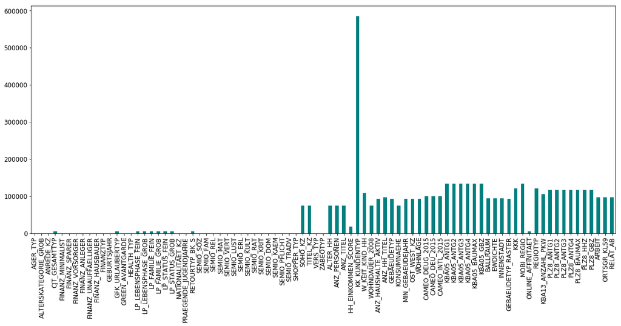

```python
# Visualizing the naturally missing data
azdias.isnull().sum().plot.bar(figsize=(20,8),fontsize=12,color='teal');
```

```python
# Deeper analysis of the variable KK_KUNDENTYP - Consumer pattern over 12 months
azdias['KK_KUNDENTYP'].value_counts()
```

```
3.0    65151
2.0    62564
5.0    48038
4.0    44512
6.0    44114
1.0    42230
Name: KK_KUNDENTYP, dtype: int64
```

```python
# Identify missing or unknown data values and convert them to NaNs.
def convert_missing_to_nan(df):
    for i,V in enumerate(df.iteritems()):
        missing_unknown = feat_info['missing_or_unknown'][i]
        column_name = V[0]
        missing_unknown = missing_unknown[1:-1].split(',')
        if missing_unknown != ['']:
            hold = []
            for x in missing_unknown:
                if x in ['X','XX']:
                    hold.append(x)
                else:
                    hold.append(int(x))
            df[column_name] = df[column_name].replace(hold,np.nan)

    return df
```

```python
azdias = convert_missing_to_nan(azdias)
```

#### Step 1.1.2: Assess Missing Data in Each Column

How much missing data is present in each column? There are a few columns that are outliers in terms of the proportion of values that are missing. You will want to use matplotlib's [`hist()`](https://matplotlib.org/api/_as_gen/matplotlib.pyplot.hist.html) function to visualize the distribution of missing value counts to find these columns. Identify and document these columns. While some of these columns might have justifications for keeping or re-encoding the data, for this project you should just remove them from the dataframe. (Feel free to make remarks about these outlier columns in the discussion, however!)

For the remaining features, are there any patterns in which columns have, or share, missing data?

```python
# Perform an assessment of how much missing data there is in each column of the
# dataset.
azdias.isnull().sum()
```

```
AGER_TYP                 685843
ALTERSKATEGORIE_GROB       2881
ANREDE_KZ                     0
CJT_GESAMTTYP              4854
FINANZ_MINIMALIST             0
FINANZ_SPARER                 0
FINANZ_VORSORGER              0
FINANZ_ANLEGER                0
FINANZ_UNAUFFAELLIGER         0
FINANZ_HAUSBAUER              0
FINANZTYP                     0
GEBURTSJAHR              392318
GFK_URLAUBERTYP            4854
GREEN_AVANTGARDE              0
HEALTH_TYP               111196
LP_LEBENSPHASE_FEIN       97632
LP_LEBENSPHASE_GROB       94572
LP_FAMILIE_FEIN           77792
LP_FAMILIE_GROB           77792
LP_STATUS_FEIN             4854
LP_STATUS_GROB             4854
NATIONALITAET_KZ         108315
PRAEGENDE_JUGENDJAHRE    108164
RETOURTYP_BK_S             4854
SEMIO_SOZ                     0
SEMIO_FAM                     0
SEMIO_REL                     0
SEMIO_MAT                     0
SEMIO_VERT                    0
SEMIO_LUST                    0
                          ...
OST_WEST_KZ               93148
WOHNLAGE                  93148
CAMEO_DEUG_2015           99352
CAMEO_DEU_2015            99352
CAMEO_INTL_2015           99352
KBA05_ANTG1              133324
KBA05_ANTG2              133324
KBA05_ANTG3              133324
KBA05_ANTG4              133324
KBA05_BAUMAX             476524
KBA05_GBZ                133324
BALLRAUM                  93740
EWDICHTE                  93740
INNENSTADT                93740
GEBAEUDETYP_RASTER        93155
KKK                      158064
MOBI_REGIO               133324
ONLINE_AFFINITAET          4854
REGIOTYP                 158064
KBA13_ANZAHL_PKW         105800
PLZ8_ANTG1               116515
PLZ8_ANTG2               116515
PLZ8_ANTG3               116515
PLZ8_ANTG4               116515
PLZ8_BAUMAX              116515
PLZ8_HHZ                 116515
PLZ8_GBZ                 116515
ARBEIT                    97375
ORTSGR_KLS9               97274
RELAT_AB                  97375
Length: 85, dtype: int64
```

```python
sum(azdias.isnull().sum())
```

```
8373929
```

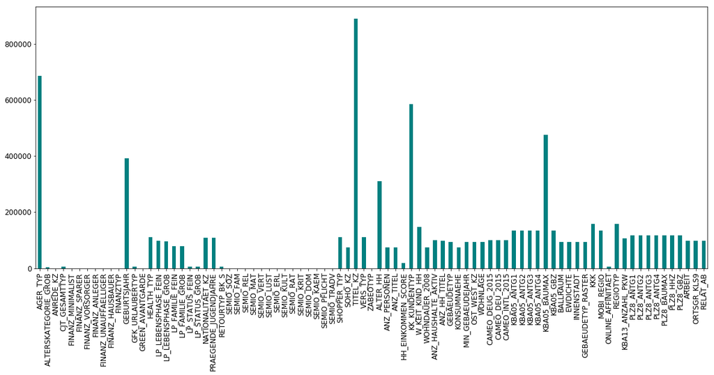

```python
#Visualizing the columns with missing values
azdias.isnull().sum().plot.bar(figsize=(20,8),fontsize=12,color='teal');
```

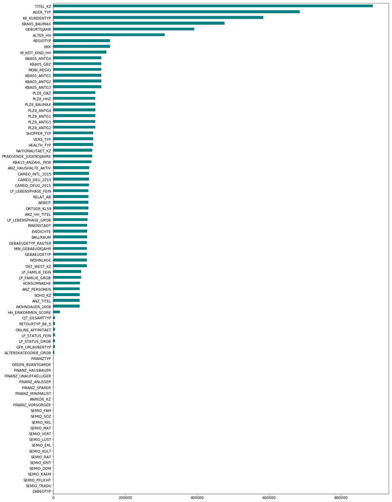

```python
# Visualizing the missing data for each column sorted from highest to lowest.
azdias.isnull().sum().sort_values().plot.barh(figsize=(20,30),fontsize=12,color='teal');
```

```python
# Calculating percentage of Nan values in descending order
round(azdias.isnull().sum()/azdias.shape[0]*100,1).sort_values(ascending=False)
```

```
TITEL_KZ                 99.8
AGER_TYP                 77.0
KK_KUNDENTYP             65.6
KBA05_BAUMAX             53.5
GEBURTSJAHR              44.0
ALTER_HH                 34.8
REGIOTYP                 17.7
KKK                      17.7
W_KEIT_KIND_HH           16.6
KBA05_ANTG4              15.0
KBA05_GBZ                15.0
MOBI_REGIO               15.0
KBA05_ANTG1              15.0
KBA05_ANTG2              15.0
KBA05_ANTG3              15.0
PLZ8_GBZ                 13.1
PLZ8_HHZ                 13.1
PLZ8_BAUMAX              13.1
PLZ8_ANTG4               13.1
PLZ8_ANTG1               13.1
PLZ8_ANTG3               13.1
PLZ8_ANTG2               13.1
SHOPPER_TYP              12.5
VERS_TYP                 12.5
HEALTH_TYP               12.5
NATIONALITAET_KZ         12.2
PRAEGENDE_JUGENDJAHRE    12.1
KBA13_ANZAHL_PKW         11.9
ANZ_HAUSHALTE_AKTIV      11.2
CAMEO_INTL_2015          11.1
                         ...
LP_STATUS_FEIN            0.5
CJT_GESAMTTYP             0.5
GFK_URLAUBERTYP           0.5
LP_STATUS_GROB            0.5
RETOURTYP_BK_S            0.5
ALTERSKATEGORIE_GROB      0.3
FINANZ_MINIMALIST         0.0
ANREDE_KZ                 0.0
FINANZ_SPARER             0.0
GREEN_AVANTGARDE          0.0
FINANZTYP                 0.0
FINANZ_HAUSBAUER          0.0
FINANZ_UNAUFFAELLIGER     0.0
FINANZ_ANLEGER            0.0
FINANZ_VORSORGER          0.0
SEMIO_SOZ                 0.0
SEMIO_FAM                 0.0
SEMIO_REL                 0.0
SEMIO_MAT                 0.0
SEMIO_VERT                0.0
SEMIO_LUST                0.0
SEMIO_ERL                 0.0
SEMIO_KULT                0.0
SEMIO_RAT                 0.0
SEMIO_KRIT                0.0
SEMIO_DOM                 0.0
SEMIO_KAEM                0.0
SEMIO_PFLICHT             0.0
SEMIO_TRADV               0.0
ZABEOTYP                  0.0
Length: 85, dtype: float64
```

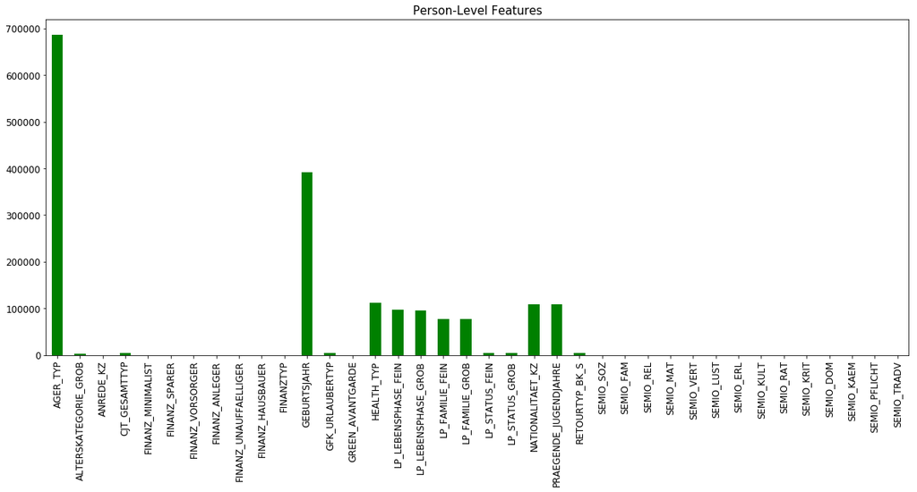

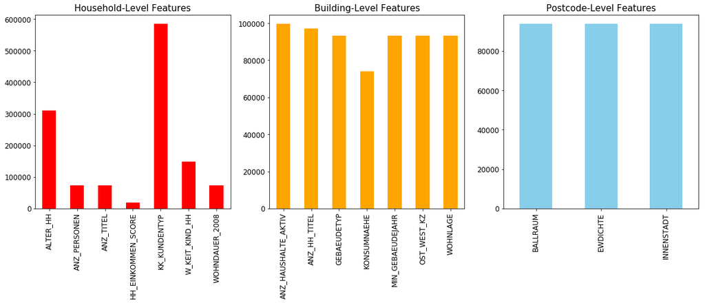

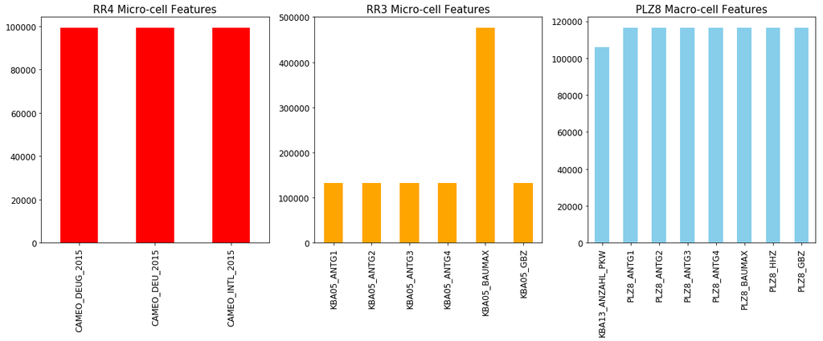

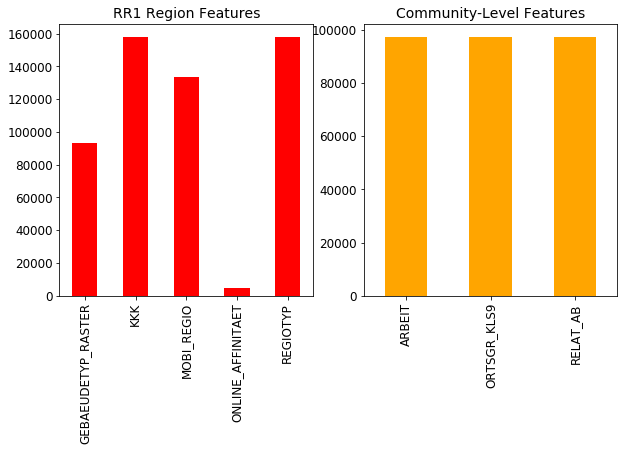

```python
# Investigate patterns in the amount of missing data in each column.
plt.figure(1,figsize=(20,8))
plt.subplot(111)
azdias.loc[:,'AGER_TYP':'SEMIO_TRADV'].isnull().sum().plot.bar(fontsize=12,color='green')
plt.title('Person-Level Features',fontsize=15)

plt.figure(2,figsize=(20,6))
plt.subplot(131)
azdias.loc[:,'ALTER_HH':'WOHNDAUER_2008'].isnull().sum().plot.bar(fontsize=12,color='red')
plt.title('Household-Level Features',fontsize=15)

plt.subplot(132)
azdias.loc[:,'ANZ_HAUSHALTE_AKTIV':'WOHNLAGE'].isnull().sum().plot.bar(fontsize=12,color='orange')
plt.title('Building-Level Features',fontsize=15)

plt.subplot(133)
azdias.loc[:,'BALLRAUM':'INNENSTADT'].isnull().sum().plot.bar(fontsize=12,color='skyblue')
plt.title('Postcode-Level Features',fontsize=15)

plt.figure(3,figsize=(20,6))
plt.subplot(131)
azdias.loc[:,'CAMEO_DEUG_2015':'CAMEO_INTL_2015'].isnull().sum().plot.bar(fontsize=12,color='red')
plt.title('RR4 Micro-cell Features',fontsize=15)

plt.subplot(132)
azdias.loc[:,'KBA05_ANTG1':'KBA05_GBZ'].isnull().sum().plot.bar(fontsize=12,color='orange')
plt.title('RR3 Micro-cell Features',fontsize=15)

plt.subplot(133)
azdias.loc[:,'KBA13_ANZAHL_PKW':'PLZ8_GBZ'].isnull().sum().plot.bar(fontsize=12,color='skyblue')
plt.title('PLZ8 Macro-cell Features',fontsize=15)

plt.figure(4,figsize=(10,5))
plt.subplot(121)
azdias.loc[:,'GEBAEUDETYP_RASTER':'REGIOTYP'].isnull().sum().plot.bar(fontsize=12,color='red')
plt.title('RR1 Region Features',fontsize=14)

plt.subplot(122)
azdias.loc[:,'ARBEIT':'RELAT_AB'].isnull().sum().plot.bar(fontsize=12,color='orange')
plt.title('Community-Level Features',fontsize=14)

plt.show()
```

```python
# Remove the outlier columns from the dataset. (You'll perform other data
# engineering tasks such as re-encoding and imputation later.)

azdias = azdias.drop(['TITEL_KZ','AGER_TYP','KK_KUNDENTYP','KBA05_BAUMAX','GEBURTSJAHR','ALTER_HH'],axis=1)
azdias[:10]
```

|  | ALTERSKATEGORIE_GROB | ANREDE_KZ | CJT_GESAMTTYP | FINANZ_MINIMALIST | FINANZ_SPARER | FINANZ_VORSORGER | FINANZ_ANLEGER | FINANZ_UNAUFFAELLIGER | FINANZ_HAUSBAUER | FINANZTYP | ... | PLZ8_ANTG1 | PLZ8_ANTG2 | PLZ8_ANTG3 | PLZ8_ANTG4 | PLZ8_BAUMAX | PLZ8_HHZ | PLZ8_GBZ | ARBEIT | ORTSGR_KLS9 | RELAT_AB |
| --- | --- | --- | --- | --- | --- | --- | --- | --- | --- | --- | --- | --- | --- | --- | --- | --- | --- | --- | --- | --- | --- |
| 0 | 2.0 | 1 | 2.0 | 3 | 4 | 3 | 5 | 5 | 3 | 4 | ... | NaN | NaN | NaN | NaN | NaN | NaN | NaN | NaN | NaN | NaN |
| 1 | 1.0 | 2 | 5.0 | 1 | 5 | 2 | 5 | 4 | 5 | 1 | ... | 2.0 | 3.0 | 2.0 | 1.0 | 1.0 | 5.0 | 4.0 | 3.0 | 5.0 | 4.0 |
| 2 | 3.0 | 2 | 3.0 | 1 | 4 | 1 | 2 | 3 | 5 | 1 | ... | 3.0 | 3.0 | 1.0 | 0.0 | 1.0 | 4.0 | 4.0 | 3.0 | 5.0 | 2.0 |
| 3 | 4.0 | 2 | 2.0 | 4 | 2 | 5 | 2 | 1 | 2 | 6 | ... | 2.0 | 2.0 | 2.0 | 0.0 | 1.0 | 3.0 | 4.0 | 2.0 | 3.0 | 3.0 |
| 4 | 3.0 | 1 | 5.0 | 4 | 3 | 4 | 1 | 3 | 2 | 5 | ... | 2.0 | 4.0 | 2.0 | 1.0 | 2.0 | 3.0 | 3.0 | 4.0 | 6.0 | 5.0 |
| 5 | 1.0 | 2 | 2.0 | 3 | 1 | 5 | 2 | 2 | 5 | 2 | ... | 2.0 | 3.0 | 1.0 | 1.0 | 1.0 | 5.0 | 5.0 | 2.0 | 3.0 | 3.0 |
| 6 | 2.0 | 2 | 5.0 | 1 | 5 | 1 | 5 | 4 | 3 | 4 | ... | 3.0 | 3.0 | 1.0 | 0.0 | 1.0 | 5.0 | 5.0 | 4.0 | 6.0 | 3.0 |
| 7 | 1.0 | 1 | 3.0 | 3 | 3 | 4 | 1 | 3 | 2 | 5 | ... | 3.0 | 3.0 | 1.0 | 0.0 | 1.0 | 4.0 | 4.0 | 2.0 | 5.0 | 2.0 |
| 8 | 3.0 | 1 | 3.0 | 4 | 4 | 2 | 4 | 2 | 2 | 6 | ... | 2.0 | 3.0 | 2.0 | 1.0 | 1.0 | 3.0 | 3.0 | 2.0 | 4.0 | 3.0 |
| 9 | 3.0 | 2 | 4.0 | 2 | 4 | 2 | 3 | 5 | 4 | 1 | ... | 2.0 | 3.0 | 2.0 | 1.0 | 1.0 | 3.0 | 3.0 | 2.0 | 3.0 | 1.0 |

10 rows × 79 columns

```python
azdias.shape
```

```
(891221, 79)
```

#### Discussion 1.1.2: Assess Missing Data in Each Column

From the analysis of the naturally missing data, I can see that the person-level features is the most complete with the least number of missing observations. The data seems to have been collected and assembled by feature level, as 5 of the 9 feature levels contain the same number of missing observations, namely RR4 Micro-cell has 98,979 missing observations, RR3 Micro-cell 133,324, Postcode-level 93,740, PLZ8 Macro-cell 116,515 and Community-level 97,216 missing observations. In the person-level features, there are 9 columns with 4,854 observations missing.

"KK_Kundentyp" has the greatest number of observations missing at 584,612 observations or 66%. This category relates to consumer pattern over the past 12 months, so the presumption is missing observations were people from the population who were not a customer of the mail order company in the last 12 months. I think this column can de dropped from the dataset as the information is not useful in obtaining customer segments from the population. This information is part of the customer dataset. Decision drop "KK_Kundentyp".

Once the function to convert missing values from the feature summary file is added to the dataset, we have an increase in missing observations of 71% from 4,896,838 to 8,373,929. When we graph this data we can see 6 columns clearly stand out, all with over 30% missing information. Looking at each of the columns individually to determine their significance; "KK_Kundentyp" was discussed above. "TITEL_KZ" relates to an academic title and with 99.8% missing observations, this is a no brainer but to drop the column. "AGER_TYP" relates to a split in elderly persons, this information is partially found in other categories and can be also safely dropped without losing value. "KBA05_BAUMAX" is a summary of categories 5.1,5.2,5.3,5.4 and so can be safely dropped. "GEBURTSJAHR" relates to year of birth, since this information is genaralized in other person-level categories and with 44% of the information missing, imputing wouldn't make sense so I think better to drop also this column. Lastly "ALTER_HH" is again related to the date of birth of the head of the household and can be dropped for the same reasons as "GEBURTSJAHR".

Decision drop the 6 outlier columns of "TITEL_KZ", "AGER_TYP", "KK_KUDENTYP", "KBA05_BAUMAX", "GEBURTSJAHR" and "ALTER_HH".

#### Step 1.1.3: Assess Missing Data in Each Row

Now, you'll perform a similar assessment for the rows of the dataset. How much data is missing in each row? As with the columns, you should see some groups of points that have a very different numbers of missing values. Divide the data into two subsets: one for data points that are above some threshold for missing values, and a second subset for points below that threshold.

In order to know what to do with the outlier rows, we should see if the distribution of data values on columns that are not missing data (or are missing very little data) are similar or different between the two groups. Select at least five of these columns and compare the distribution of values.

- You can use seaborn's [`countplot()`](https://seaborn.pydata.org/generated/seaborn.countplot.html) function to create a bar chart of code frequencies and matplotlib's [`subplot()`](https://matplotlib.org/api/_as_gen/matplotlib.pyplot.subplot.html) function to put bar charts for the two subplots side by side.
- To reduce repeated code, you might want to write a function that can perform this comparison, taking as one of its arguments a column to be compared.

Depending on what you observe in your comparison, this will have implications on how you approach your conclusions later in the analysis. If the distributions of non-missing features look similar between the data with many missing values and the data with few or no missing values, then we could argue that simply dropping those points from the analysis won't present a major issue. On the other hand, if the data with many missing values looks very different from the data with few or no missing values, then we should make a note on those data as special. We'll revisit these data later on. **Either way, you should continue your analysis for now using just the subset of the data with few or no missing values.**

```python
# How much data is missing in each row of the dataset?
missing_row_data = azdias.isnull().sum(axis=1)
missing_row_data
```

```
0         43
1          0
2          0
3          7
4          0
5          0
6          0
7          0
8          0
9          0
10         0
11        47
12         6
13         8
14        47
```

[output cut: 47 more lines]

```python
# Aggregate missing row data by number of missing values per row
missing_row_data.value_counts().sort_index()
```

```
0     623209
1      15738
2      27926
3      17629
4      12607
5      22515
6      13771
7      13714
8      24592
9       3042
10      5410
11      1127
12       766
13      3255
14      2243
```

[output cut: 35 more lines]

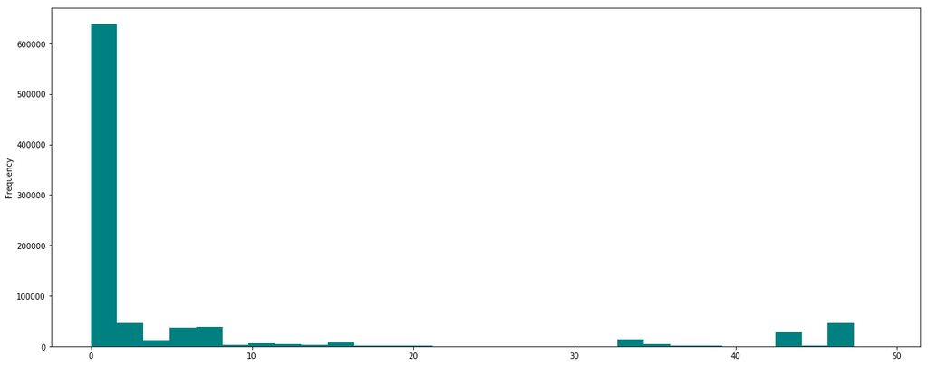

```python
# Visualize counts of number of missing data points by row
missing_row_data.plot(kind='hist',bins=30,figsize=(20,8),color='teal');
```

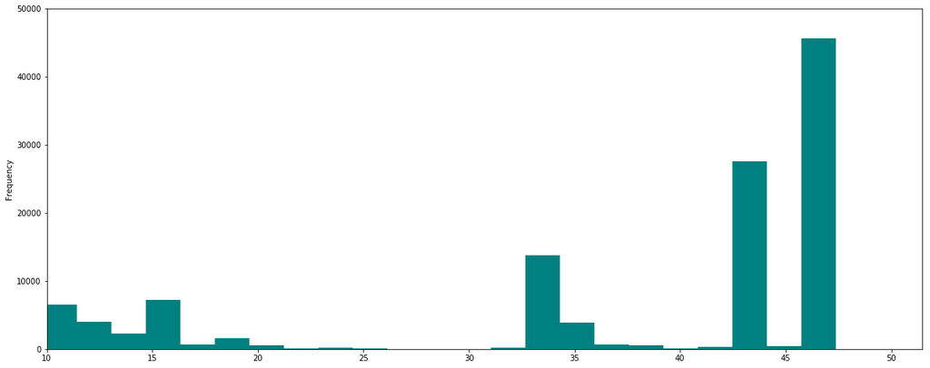

```python
# Zoom in on missing rows from 10 missing data points
missing_row_data.plot(kind='hist',bins=30,figsize=(20,8),color='teal',xlim=10,ylim=(0,50000));
```

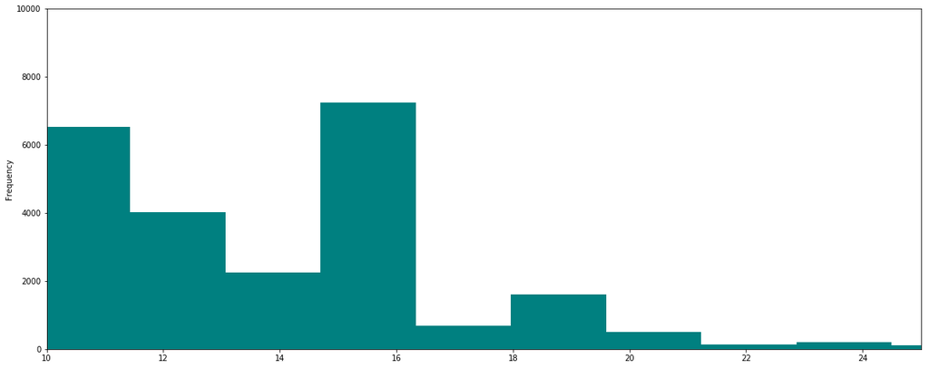

```python
#Zoom in on area from 10 to 25 missing data points
missing_row_data.plot(kind='hist',bins=30,figsize=(20,8),color='teal',xlim=(10,25),ylim=(0,10000));
```